# Risk Factor Analysis

## Outcome Variable

**Outcome Variable:** wast_rec90d

## Predictor Variables

**Intervention Variable:** anywast06

**Adjustment Set:**

unadjusted

## Stratifying Variables

The analysis was stratified on these variable(s):

- agecat
- studyid
- country

## Data Summary

| agecat | studyid | country | anywast06 | wast_rec90d | n_cell | n |
| --- | --- | --- | --- | --- | --- | --- |
| 0-24 months | ki0047075b-MAL-ED | BANGLADESH | 0 | 0 | 20 | 124 |
| 0-24 months | ki0047075b-MAL-ED | BANGLADESH | 0 | 1 | 20 | 124 |
| 0-24 months | ki0047075b-MAL-ED | BANGLADESH | 1 | 0 | 25 | 124 |
| 0-24 months | ki0047075b-MAL-ED | BANGLADESH | 1 | 1 | 59 | 124 |
| 0-24 months | ki0047075b-MAL-ED | BRAZIL | 0 | 0 | 5 | 23 |
| 0-24 months | ki0047075b-MAL-ED | BRAZIL | 0 | 1 | 3 | 23 |
| 0-24 months | ki0047075b-MAL-ED | BRAZIL | 1 | 0 | 1 | 23 |
| 0-24 months | ki0047075b-MAL-ED | BRAZIL | 1 | 1 | 14 | 23 |
| 0-24 months | ki0047075b-MAL-ED | INDIA | 0 | 0 | 23 | 178 |
| 0-24 months | ki0047075b-MAL-ED | INDIA | 0 | 1 | 35 | 178 |
| 0-24 months | ki0047075b-MAL-ED | INDIA | 1 | 0 | 48 | 178 |
| 0-24 months | ki0047075b-MAL-ED | INDIA | 1 | 1 | 72 | 178 |
| 0-24 months | ki0047075b-MAL-ED | NEPAL | 0 | 0 | 6 | 93 |
| 0-24 months | ki0047075b-MAL-ED | NEPAL | 0 | 1 | 28 | 93 |
| 0-24 months | ki0047075b-MAL-ED | NEPAL | 1 | 0 | 14 | 93 |
| 0-24 months | ki0047075b-MAL-ED | NEPAL | 1 | 1 | 45 | 93 |
| 0-24 months | ki0047075b-MAL-ED | PERU | 0 | 0 | 5 | 34 |
| 0-24 months | ki0047075b-MAL-ED | PERU | 0 | 1 | 16 | 34 |
| 0-24 months | ki0047075b-MAL-ED | PERU | 1 | 0 | 1 | 34 |
| 0-24 months | ki0047075b-MAL-ED | PERU | 1 | 1 | 12 | 34 |
| 0-24 months | ki0047075b-MAL-ED | SOUTH AFRICA | 0 | 0 | 8 | 83 |
| 0-24 months | ki0047075b-MAL-ED | SOUTH AFRICA | 0 | 1 | 32 | 83 |
| 0-24 months | ki0047075b-MAL-ED | SOUTH AFRICA | 1 | 0 | 9 | 83 |
| 0-24 months | ki0047075b-MAL-ED | SOUTH AFRICA | 1 | 1 | 34 | 83 |
| 0-24 months | ki0047075b-MAL-ED | TANZANIA, UNITED REPUBLIC OF | 0 | 0 | 5 | 45 |
| 0-24 months | ki0047075b-MAL-ED | TANZANIA, UNITED REPUBLIC OF | 0 | 1 | 20 | 45 |
| 0-24 months | ki0047075b-MAL-ED | TANZANIA, UNITED REPUBLIC OF | 1 | 0 | 3 | 45 |
| 0-24 months | ki0047075b-MAL-ED | TANZANIA, UNITED REPUBLIC OF | 1 | 1 | 17 | 45 |
| 0-24 months | ki1000108-CMC-V-BCS-2002 | INDIA | 0 | 0 | 21 | 325 |
| 0-24 months | ki1000108-CMC-V-BCS-2002 | INDIA | 0 | 1 | 23 | 325 |

[output cut: 198 more lines]

The following strata were considered:

- agecat: 0-24 months, studyid: ki0047075b-MAL-ED, country: BANGLADESH
- agecat: 0-24 months, studyid: ki0047075b-MAL-ED, country: BRAZIL
- agecat: 0-24 months, studyid: ki0047075b-MAL-ED, country: INDIA
- agecat: 0-24 months, studyid: ki0047075b-MAL-ED, country: NEPAL
- agecat: 0-24 months, studyid: ki0047075b-MAL-ED, country: PERU
- agecat: 0-24 months, studyid: ki0047075b-MAL-ED, country: SOUTH AFRICA
- agecat: 0-24 months, studyid: ki0047075b-MAL-ED, country: TANZANIA, UNITED REPUBLIC OF
- agecat: 0-24 months, studyid: ki1000108-CMC-V-BCS-2002, country: INDIA
- agecat: 0-24 months, studyid: ki1000108-IRC, country: INDIA
- agecat: 0-24 months, studyid: ki1000109-EE, country: PAKISTAN
- agecat: 0-24 months, studyid: ki1000109-ResPak, country: PAKISTAN
- agecat: 0-24 months, studyid: ki1017093b-PROVIDE, country: BANGLADESH
- agecat: 0-24 months, studyid: ki1066203-TanzaniaChild2, country: TANZANIA, UNITED REPUBLIC OF
- agecat: 0-24 months, studyid: ki1101329-Keneba, country: GAMBIA
- agecat: 0-24 months, studyid: ki1112895-Guatemala BSC, country: GUATEMALA
- agecat: 0-24 months, studyid: ki1113344-GMS-Nepal, country: NEPAL
- agecat: 0-24 months, studyid: ki1114097-CMIN, country: BANGLADESH
- agecat: 0-24 months, studyid: ki1114097-CMIN, country: PERU
- agecat: 0-24 months, studyid: ki1114097-CONTENT, country: PERU
- agecat: 0-6 months, studyid: ki0047075b-MAL-ED, country: BANGLADESH
- agecat: 0-6 months, studyid: ki0047075b-MAL-ED, country: BRAZIL
- agecat: 0-6 months, studyid: ki0047075b-MAL-ED, country: INDIA
- agecat: 0-6 months, studyid: ki0047075b-MAL-ED, country: NEPAL
- agecat: 0-6 months, studyid: ki0047075b-MAL-ED, country: PERU
- agecat: 0-6 months, studyid: ki0047075b-MAL-ED, country: SOUTH AFRICA
- agecat: 0-6 months, studyid: ki0047075b-MAL-ED, country: TANZANIA, UNITED REPUBLIC OF
- agecat: 0-6 months, studyid: ki1000108-CMC-V-BCS-2002, country: INDIA
- agecat: 0-6 months, studyid: ki1000108-IRC, country: INDIA
- agecat: 0-6 months, studyid: ki1000109-EE, country: PAKISTAN
- agecat: 0-6 months, studyid: ki1000109-ResPak, country: PAKISTAN
- agecat: 0-6 months, studyid: ki1017093b-PROVIDE, country: BANGLADESH
- agecat: 0-6 months, studyid: ki1066203-TanzaniaChild2, country: TANZANIA, UNITED REPUBLIC OF
- agecat: 0-6 months, studyid: ki1101329-Keneba, country: GAMBIA
- agecat: 0-6 months, studyid: ki1112895-Guatemala BSC, country: GUATEMALA
- agecat: 0-6 months, studyid: ki1113344-GMS-Nepal, country: NEPAL
- agecat: 0-6 months, studyid: ki1114097-CMIN, country: BANGLADESH
- agecat: 0-6 months, studyid: ki1114097-CMIN, country: PERU
- agecat: 0-6 months, studyid: ki1114097-CONTENT, country: PERU
- agecat: 6-24 months, studyid: ki0047075b-MAL-ED, country: BANGLADESH
- agecat: 6-24 months, studyid: ki0047075b-MAL-ED, country: BRAZIL
- agecat: 6-24 months, studyid: ki0047075b-MAL-ED, country: INDIA
- agecat: 6-24 months, studyid: ki0047075b-MAL-ED, country: NEPAL
- agecat: 6-24 months, studyid: ki0047075b-MAL-ED, country: PERU
- agecat: 6-24 months, studyid: ki0047075b-MAL-ED, country: SOUTH AFRICA
- agecat: 6-24 months, studyid: ki0047075b-MAL-ED, country: TANZANIA, UNITED REPUBLIC OF
- agecat: 6-24 months, studyid: ki1000108-CMC-V-BCS-2002, country: INDIA
- agecat: 6-24 months, studyid: ki1000108-IRC, country: INDIA
- agecat: 6-24 months, studyid: ki1000109-EE, country: PAKISTAN
- agecat: 6-24 months, studyid: ki1000109-ResPak, country: PAKISTAN
- agecat: 6-24 months, studyid: ki1017093b-PROVIDE, country: BANGLADESH
- agecat: 6-24 months, studyid: ki1066203-TanzaniaChild2, country: TANZANIA, UNITED REPUBLIC OF
- agecat: 6-24 months, studyid: ki1101329-Keneba, country: GAMBIA
- agecat: 6-24 months, studyid: ki1112895-Guatemala BSC, country: GUATEMALA
- agecat: 6-24 months, studyid: ki1113344-GMS-Nepal, country: NEPAL
- agecat: 6-24 months, studyid: ki1114097-CMIN, country: BANGLADESH
- agecat: 6-24 months, studyid: ki1114097-CMIN, country: PERU
- agecat: 6-24 months, studyid: ki1114097-CONTENT, country: PERU

### Dropped Strata

Some strata were dropped due to rare outcomes:

- agecat: 0-24 months, studyid: ki0047075b-MAL-ED, country: BRAZIL
- agecat: 0-24 months, studyid: ki0047075b-MAL-ED, country: PERU
- agecat: 0-24 months, studyid: ki0047075b-MAL-ED, country: TANZANIA, UNITED REPUBLIC OF
- agecat: 0-24 months, studyid: ki1112895-Guatemala BSC, country: GUATEMALA
- agecat: 0-24 months, studyid: ki1114097-CONTENT, country: PERU
- agecat: 0-6 months, studyid: ki0047075b-MAL-ED, country: BANGLADESH
- agecat: 0-6 months, studyid: ki0047075b-MAL-ED, country: BRAZIL
- agecat: 0-6 months, studyid: ki0047075b-MAL-ED, country: INDIA
- agecat: 0-6 months, studyid: ki0047075b-MAL-ED, country: NEPAL
- agecat: 0-6 months, studyid: ki0047075b-MAL-ED, country: PERU
- agecat: 0-6 months, studyid: ki0047075b-MAL-ED, country: SOUTH AFRICA
- agecat: 0-6 months, studyid: ki0047075b-MAL-ED, country: TANZANIA, UNITED REPUBLIC OF
- agecat: 0-6 months, studyid: ki1000108-CMC-V-BCS-2002, country: INDIA
- agecat: 0-6 months, studyid: ki1000108-IRC, country: INDIA
- agecat: 0-6 months, studyid: ki1000109-EE, country: PAKISTAN
- agecat: 0-6 months, studyid: ki1000109-ResPak, country: PAKISTAN
- agecat: 0-6 months, studyid: ki1017093b-PROVIDE, country: BANGLADESH
- agecat: 0-6 months, studyid: ki1066203-TanzaniaChild2, country: TANZANIA, UNITED REPUBLIC OF
- agecat: 0-6 months, studyid: ki1101329-Keneba, country: GAMBIA
- agecat: 0-6 months, studyid: ki1112895-Guatemala BSC, country: GUATEMALA
- agecat: 0-6 months, studyid: ki1113344-GMS-Nepal, country: NEPAL
- agecat: 0-6 months, studyid: ki1114097-CMIN, country: BANGLADESH
- agecat: 0-6 months, studyid: ki1114097-CMIN, country: PERU
- agecat: 0-6 months, studyid: ki1114097-CONTENT, country: PERU
- agecat: 6-24 months, studyid: ki0047075b-MAL-ED, country: BRAZIL
- agecat: 6-24 months, studyid: ki0047075b-MAL-ED, country: PERU
- agecat: 6-24 months, studyid: ki0047075b-MAL-ED, country: SOUTH AFRICA
- agecat: 6-24 months, studyid: ki0047075b-MAL-ED, country: TANZANIA, UNITED REPUBLIC OF
- agecat: 6-24 months, studyid: ki1112895-Guatemala BSC, country: GUATEMALA
- agecat: 6-24 months, studyid: ki1114097-CMIN, country: PERU
- agecat: 6-24 months, studyid: ki1114097-CONTENT, country: PERU

## Methods Detail

We’re interested in the causal parameters $E[Y_a]$ for all values of $a \in \mathcal{A}$. These parameters represent the mean outcome if, possibly contrary to fact, we intervened to set all units to have $A=a$. Under the randomization and positivity assumptions, these are identified by the statistical parameters $\psi_a=E_W[E_{Y|A,W}(Y|A=a,W)]$. In addition, we’re interested in the mean of $Y$, $E[Y]$ under no intervention (the observed mean). We will estimate these parameters by using SuperLearner to fit the relevant likelihood factors – $E_{Y|A,W}(Y|A=a,W)$ and $p(A=a|W)$, and then updating our likelihood fit using a joint TMLE.

For unadjusted analyses ($W=\{\}$), initial likelihoods were estimated using Lrnr_glm to estimate the simple $E(Y|A)$ and Lrnr_mean to estimate $p(A)$. For adjusted analyses, a small library containing Lrnr_glmnet, Lrnr_xgboost, and Lrnr_mean was used.

Having estimated these parameters, we will then use the delta method to estimate relative risks and attributable risks relative to a prespecified baseline level of $A$.

# Results Detail

## Results Plots

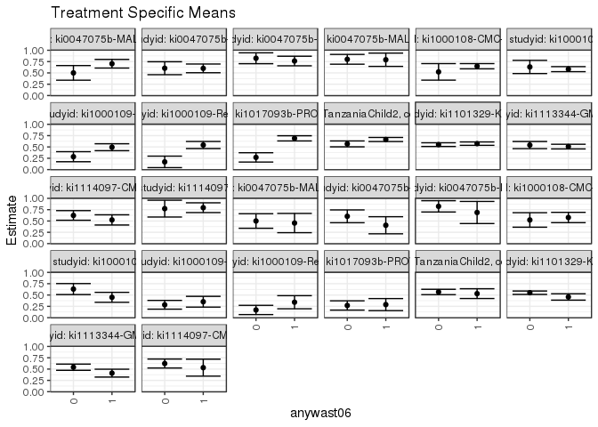

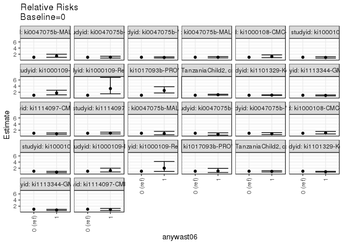

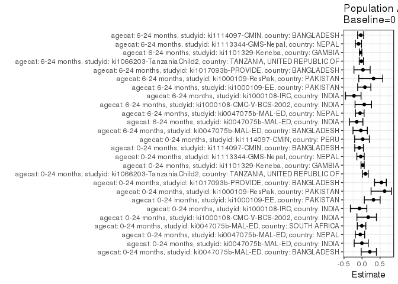

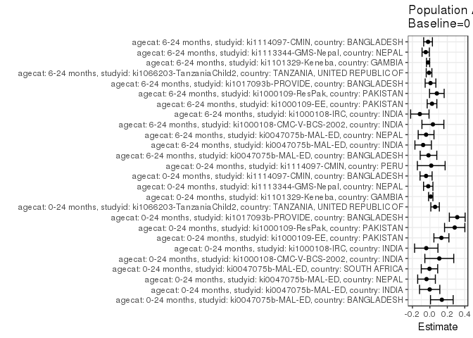

## Results Table

### Parameter: TSM

| agecat | studyid | country | intervention_level | baseline_level | estimate | ci_lower | ci_upper |
| --- | --- | --- | --- | --- | --- | --- | --- |
| 0-24 months | ki0047075b-MAL-ED | BANGLADESH | 0 | NA | 0.5000000 | 0.3382483 | 0.6617517 |
| 0-24 months | ki0047075b-MAL-ED | BANGLADESH | 1 | NA | 0.7023810 | 0.6068304 | 0.7979315 |
| 0-24 months | ki0047075b-MAL-ED | INDIA | 0 | NA | 0.6034483 | 0.4600805 | 0.7468161 |
| 0-24 months | ki0047075b-MAL-ED | INDIA | 1 | NA | 0.6000000 | 0.5039386 | 0.6960614 |
| 0-24 months | ki0047075b-MAL-ED | NEPAL | 0 | NA | 0.8235294 | 0.7031848 | 0.9438740 |
| 0-24 months | ki0047075b-MAL-ED | NEPAL | 1 | NA | 0.7627119 | 0.6570877 | 0.8683360 |
| 0-24 months | ki0047075b-MAL-ED | SOUTH AFRICA | 0 | NA | 0.8000000 | 0.6919739 | 0.9080261 |
| 0-24 months | ki0047075b-MAL-ED | SOUTH AFRICA | 1 | NA | 0.7906977 | 0.6440188 | 0.9373766 |
| 0-24 months | ki1000108-CMC-V-BCS-2002 | INDIA | 0 | NA | 0.5227273 | 0.3399994 | 0.7054552 |
| 0-24 months | ki1000108-CMC-V-BCS-2002 | INDIA | 1 | NA | 0.6476868 | 0.5899744 | 0.7053993 |
| 0-24 months | ki1000108-IRC | INDIA | 0 | NA | 0.6315789 | 0.4855959 | 0.7775620 |
| 0-24 months | ki1000108-IRC | INDIA | 1 | NA | 0.5828402 | 0.5270477 | 0.6386327 |
| 0-24 months | ki1000109-EE | PAKISTAN | 0 | NA | 0.2842105 | 0.1732100 | 0.3952111 |
| 0-24 months | ki1000109-EE | PAKISTAN | 1 | NA | 0.4938272 | 0.4173063 | 0.5703481 |
| 0-24 months | ki1000109-ResPak | PAKISTAN | 0 | NA | 0.1702128 | 0.0429124 | 0.2975131 |
| 0-24 months | ki1000109-ResPak | PAKISTAN | 1 | NA | 0.5424837 | 0.4643952 | 0.6205722 |
| 0-24 months | ki1017093b-PROVIDE | BANGLADESH | 0 | NA | 0.2692308 | 0.1664756 | 0.3719860 |
| 0-24 months | ki1017093b-PROVIDE | BANGLADESH | 1 | NA | 0.6899563 | 0.6327983 | 0.7471144 |
| 0-24 months | ki1066203-TanzaniaChild2 | TANZANIA, UNITED REPUBLIC OF | 0 | NA | 0.5672727 | 0.5023644 | 0.6321810 |
| 0-24 months | ki1066203-TanzaniaChild2 | TANZANIA, UNITED REPUBLIC OF | 1 | NA | 0.6643836 | 0.6191308 | 0.7096363 |
| 0-24 months | ki1101329-Keneba | GAMBIA | 0 | NA | 0.5512821 | 0.5102869 | 0.5922772 |
| 0-24 months | ki1101329-Keneba | GAMBIA | 1 | NA | 0.5727700 | 0.5352381 | 0.6103018 |
| 0-24 months | ki1113344-GMS-Nepal | NEPAL | 0 | NA | 0.5413223 | 0.4622920 | 0.6203526 |
| 0-24 months | ki1113344-GMS-Nepal | NEPAL | 1 | NA | 0.5078370 | 0.4565669 | 0.5591071 |
| 0-24 months | ki1114097-CMIN | BANGLADESH | 0 | NA | 0.6226415 | 0.5160433 | 0.7292397 |
| 0-24 months | ki1114097-CMIN | BANGLADESH | 1 | NA | 0.5238095 | 0.4112354 | 0.6363837 |
| 0-24 months | ki1114097-CMIN | PERU | 0 | NA | 0.7727273 | 0.5872088 | 0.9582457 |
| 0-24 months | ki1114097-CMIN | PERU | 1 | NA | 0.7936508 | 0.6855248 | 0.9017768 |
| 6-24 months | ki0047075b-MAL-ED | BANGLADESH | 0 | NA | 0.5000000 | 0.3392126 | 0.6607874 |
| 6-24 months | ki0047075b-MAL-ED | BANGLADESH | 1 | NA | 0.4545455 | 0.2415102 | 0.6675807 |
| 6-24 months | ki0047075b-MAL-ED | INDIA | 0 | NA | 0.6034483 | 0.4619286 | 0.7449680 |
| 6-24 months | ki0047075b-MAL-ED | INDIA | 1 | NA | 0.4054054 | 0.2165504 | 0.5942604 |
| 6-24 months | ki0047075b-MAL-ED | NEPAL | 0 | NA | 0.8235294 | 0.6987335 | 0.9483254 |
| 6-24 months | ki0047075b-MAL-ED | NEPAL | 1 | NA | 0.6875000 | 0.4432765 | 0.9317235 |
| 6-24 months | ki1000108-CMC-V-BCS-2002 | INDIA | 0 | NA | 0.5227273 | 0.3626804 | 0.6827742 |
| 6-24 months | ki1000108-CMC-V-BCS-2002 | INDIA | 1 | NA | 0.5769231 | 0.4628880 | 0.6909582 |
| 6-24 months | ki1000108-IRC | INDIA | 0 | NA | 0.6315789 | 0.5100145 | 0.7531434 |
| 6-24 months | ki1000108-IRC | INDIA | 1 | NA | 0.4489796 | 0.3388111 | 0.5591481 |
| 6-24 months | ki1000109-EE | PAKISTAN | 0 | NA | 0.2842105 | 0.1875538 | 0.3808673 |
| 6-24 months | ki1000109-EE | PAKISTAN | 1 | NA | 0.3518519 | 0.2330416 | 0.4706621 |
| 6-24 months | ki1000109-ResPak | PAKISTAN | 0 | NA | 0.1702128 | 0.0679359 | 0.2724897 |
| 6-24 months | ki1000109-ResPak | PAKISTAN | 1 | NA | 0.3414634 | 0.1967303 | 0.4861965 |
| 6-24 months | ki1017093b-PROVIDE | BANGLADESH | 0 | NA | 0.2692308 | 0.1666721 | 0.3717895 |
| 6-24 months | ki1017093b-PROVIDE | BANGLADESH | 1 | NA | 0.2888889 | 0.1559347 | 0.4218431 |
| 6-24 months | ki1066203-TanzaniaChild2 | TANZANIA, UNITED REPUBLIC OF | 0 | NA | 0.5672727 | 0.5079161 | 0.6266294 |
| 6-24 months | ki1066203-TanzaniaChild2 | TANZANIA, UNITED REPUBLIC OF | 1 | NA | 0.5306122 | 0.4225460 | 0.6386785 |
| 6-24 months | ki1101329-Keneba | GAMBIA | 0 | NA | 0.5512821 | 0.5138736 | 0.5886906 |
| 6-24 months | ki1101329-Keneba | GAMBIA | 1 | NA | 0.4573991 | 0.3869214 | 0.5278768 |
| 6-24 months | ki1113344-GMS-Nepal | NEPAL | 0 | NA | 0.5413223 | 0.4728132 | 0.6098315 |
| 6-24 months | ki1113344-GMS-Nepal | NEPAL | 1 | NA | 0.4100719 | 0.3233955 | 0.4967484 |
| 6-24 months | ki1114097-CMIN | BANGLADESH | 0 | NA | 0.6226415 | 0.5235611 | 0.7217219 |
| 6-24 months | ki1114097-CMIN | BANGLADESH | 1 | NA | 0.5312500 | 0.3435485 | 0.7189515 |

### Parameter: E(Y)

| agecat | studyid | country | intervention_level | baseline_level | estimate | ci_lower | ci_upper |
| --- | --- | --- | --- | --- | --- | --- | --- |
| 0-24 months | ki0047075b-MAL-ED | BANGLADESH | NA | NA | 0.6370968 | 0.5511492 | 0.7230443 |
| 0-24 months | ki0047075b-MAL-ED | INDIA | NA | NA | 0.6011236 | 0.5212729 | 0.6809743 |
| 0-24 months | ki0047075b-MAL-ED | NEPAL | NA | NA | 0.7849462 | 0.7049947 | 0.8648978 |
| 0-24 months | ki0047075b-MAL-ED | SOUTH AFRICA | NA | NA | 0.7951807 | 0.7027530 | 0.8876084 |
| 0-24 months | ki1000108-CMC-V-BCS-2002 | INDIA | NA | NA | 0.6307692 | 0.5746323 | 0.6869062 |
| 0-24 months | ki1000108-IRC | INDIA | NA | NA | 0.5898734 | 0.5376978 | 0.6420491 |
| 0-24 months | ki1000109-EE | PAKISTAN | NA | NA | 0.4163424 | 0.3511349 | 0.4815500 |
| 0-24 months | ki1000109-ResPak | PAKISTAN | NA | NA | 0.4550000 | 0.3826235 | 0.5273765 |
| 0-24 months | ki1017093b-PROVIDE | BANGLADESH | NA | NA | 0.5830619 | 0.5262762 | 0.6398476 |
| 0-24 months | ki1066203-TanzaniaChild2 | TANZANIA, UNITED REPUBLIC OF | NA | NA | 0.6269285 | 0.5892870 | 0.6645700 |
| 0-24 months | ki1101329-Keneba | GAMBIA | NA | NA | 0.5609584 | 0.5327669 | 0.5891500 |
| 0-24 months | ki1113344-GMS-Nepal | NEPAL | NA | NA | 0.5222816 | 0.4773852 | 0.5671781 |
| 0-24 months | ki1114097-CMIN | BANGLADESH | NA | NA | 0.5789474 | 0.5004470 | 0.6574477 |
| 0-24 months | ki1114097-CMIN | PERU | NA | NA | 0.7882353 | 0.6948180 | 0.8816526 |
| 6-24 months | ki0047075b-MAL-ED | BANGLADESH | NA | NA | 0.4838710 | 0.3544124 | 0.6133295 |
| 6-24 months | ki0047075b-MAL-ED | INDIA | NA | NA | 0.5263158 | 0.4116286 | 0.6410029 |
| 6-24 months | ki0047075b-MAL-ED | NEPAL | NA | NA | 0.7800000 | 0.6617106 | 0.8982894 |
| 6-24 months | ki1000108-CMC-V-BCS-2002 | INDIA | NA | NA | 0.5573770 | 0.4641535 | 0.6506006 |
| 6-24 months | ki1000108-IRC | INDIA | NA | NA | 0.5161290 | 0.4322562 | 0.6000019 |
| 6-24 months | ki1000109-EE | PAKISTAN | NA | NA | 0.3087248 | 0.2336906 | 0.3837591 |
| 6-24 months | ki1000109-ResPak | PAKISTAN | NA | NA | 0.2500000 | 0.1614745 | 0.3385255 |
| 6-24 months | ki1017093b-PROVIDE | BANGLADESH | NA | NA | 0.2764228 | 0.1950773 | 0.3577682 |
| 6-24 months | ki1066203-TanzaniaChild2 | TANZANIA, UNITED REPUBLIC OF | NA | NA | 0.5576407 | 0.5054408 | 0.6098407 |
| 6-24 months | ki1101329-Keneba | GAMBIA | NA | NA | 0.5304088 | 0.4972641 | 0.5635534 |
| 6-24 months | ki1113344-GMS-Nepal | NEPAL | NA | NA | 0.4934383 | 0.4388573 | 0.5480193 |
| 6-24 months | ki1114097-CMIN | BANGLADESH | NA | NA | 0.6014493 | 0.5131344 | 0.6897641 |

### Parameter: RR

| agecat | studyid | country | intervention_level | baseline_level | estimate | ci_lower | ci_upper |
| --- | --- | --- | --- | --- | --- | --- | --- |
| 0-24 months | ki0047075b-MAL-ED | BANGLADESH | 0 | 0 | 1.0000000 | 1.0000000 | 1.0000000 |
| 0-24 months | ki0047075b-MAL-ED | BANGLADESH | 1 | 0 | 1.4047619 | 0.9887272 | 1.9958550 |
| 0-24 months | ki0047075b-MAL-ED | INDIA | 0 | 0 | 1.0000000 | 1.0000000 | 1.0000000 |
| 0-24 months | ki0047075b-MAL-ED | INDIA | 1 | 0 | 0.9942857 | 0.7466239 | 1.3240992 |
| 0-24 months | ki0047075b-MAL-ED | NEPAL | 0 | 0 | 1.0000000 | 1.0000000 | 1.0000000 |
| 0-24 months | ki0047075b-MAL-ED | NEPAL | 1 | 0 | 0.9261501 | 0.7569644 | 1.1331498 |
| 0-24 months | ki0047075b-MAL-ED | SOUTH AFRICA | 0 | 0 | 1.0000000 | 1.0000000 | 1.0000000 |
| 0-24 months | ki0047075b-MAL-ED | SOUTH AFRICA | 1 | 0 | 0.9883721 | 0.7861185 | 1.2426618 |
| 0-24 months | ki1000108-CMC-V-BCS-2002 | INDIA | 0 | 0 | 1.0000000 | 1.0000000 | 1.0000000 |
| 0-24 months | ki1000108-CMC-V-BCS-2002 | INDIA | 1 | 0 | 1.2390531 | 0.8638334 | 1.7772553 |
| 0-24 months | ki1000108-IRC | INDIA | 0 | 0 | 1.0000000 | 1.0000000 | 1.0000000 |
| 0-24 months | ki1000108-IRC | INDIA | 1 | 0 | 0.9228304 | 0.7186034 | 1.1850986 |
| 0-24 months | ki1000109-EE | PAKISTAN | 0 | 0 | 1.0000000 | 1.0000000 | 1.0000000 |
| 0-24 months | ki1000109-EE | PAKISTAN | 1 | 0 | 1.7375400 | 1.1414388 | 2.6449470 |
| 0-24 months | ki1000109-ResPak | PAKISTAN | 0 | 0 | 1.0000000 | 1.0000000 | 1.0000000 |
| 0-24 months | ki1000109-ResPak | PAKISTAN | 1 | 0 | 3.1870915 | 1.4880672 | 6.8260037 |
| 0-24 months | ki1017093b-PROVIDE | BANGLADESH | 0 | 0 | 1.0000000 | 1.0000000 | 1.0000000 |
| 0-24 months | ki1017093b-PROVIDE | BANGLADESH | 1 | 0 | 2.5626949 | 1.7345271 | 3.7862800 |
| 0-24 months | ki1066203-TanzaniaChild2 | TANZANIA, UNITED REPUBLIC OF | 0 | 0 | 1.0000000 | 1.0000000 | 1.0000000 |
| 0-24 months | ki1066203-TanzaniaChild2 | TANZANIA, UNITED REPUBLIC OF | 1 | 0 | 1.1711890 | 1.0251712 | 1.3380045 |
| 0-24 months | ki1101329-Keneba | GAMBIA | 0 | 0 | 1.0000000 | 1.0000000 | 1.0000000 |
| 0-24 months | ki1101329-Keneba | GAMBIA | 1 | 0 | 1.0389781 | 0.9409460 | 1.1472236 |
| 0-24 months | ki1113344-GMS-Nepal | NEPAL | 0 | 0 | 1.0000000 | 1.0000000 | 1.0000000 |
| 0-24 months | ki1113344-GMS-Nepal | NEPAL | 1 | 0 | 0.9381416 | 0.7855065 | 1.1204359 |
| 0-24 months | ki1114097-CMIN | BANGLADESH | 0 | 0 | 1.0000000 | 1.0000000 | 1.0000000 |
| 0-24 months | ki1114097-CMIN | BANGLADESH | 1 | 0 | 0.8412698 | 0.6392438 | 1.1071441 |
| 0-24 months | ki1114097-CMIN | PERU | 0 | 0 | 1.0000000 | 1.0000000 | 1.0000000 |
| 0-24 months | ki1114097-CMIN | PERU | 1 | 0 | 1.0270775 | 0.7793310 | 1.3535818 |
| 6-24 months | ki0047075b-MAL-ED | BANGLADESH | 0 | 0 | 1.0000000 | 1.0000000 | 1.0000000 |
| 6-24 months | ki0047075b-MAL-ED | BANGLADESH | 1 | 0 | 0.9090909 | 0.5154537 | 1.6033377 |
| 6-24 months | ki0047075b-MAL-ED | INDIA | 0 | 0 | 1.0000000 | 1.0000000 | 1.0000000 |
| 6-24 months | ki0047075b-MAL-ED | INDIA | 1 | 0 | 0.6718147 | 0.3989329 | 1.1313555 |
| 6-24 months | ki0047075b-MAL-ED | NEPAL | 0 | 0 | 1.0000000 | 1.0000000 | 1.0000000 |
| 6-24 months | ki0047075b-MAL-ED | NEPAL | 1 | 0 | 0.8348214 | 0.5674654 | 1.2281397 |
| 6-24 months | ki1000108-CMC-V-BCS-2002 | INDIA | 0 | 0 | 1.0000000 | 1.0000000 | 1.0000000 |
| 6-24 months | ki1000108-CMC-V-BCS-2002 | INDIA | 1 | 0 | 1.1036789 | 0.7666178 | 1.5889367 |
| 6-24 months | ki1000108-IRC | INDIA | 0 | 0 | 1.0000000 | 1.0000000 | 1.0000000 |
| 6-24 months | ki1000108-IRC | INDIA | 1 | 0 | 0.7108844 | 0.5204010 | 0.9710906 |
| 6-24 months | ki1000109-EE | PAKISTAN | 0 | 0 | 1.0000000 | 1.0000000 | 1.0000000 |
| 6-24 months | ki1000109-EE | PAKISTAN | 1 | 0 | 1.2379973 | 0.7663491 | 1.9999204 |
| 6-24 months | ki1000109-ResPak | PAKISTAN | 0 | 0 | 1.0000000 | 1.0000000 | 1.0000000 |
| 6-24 months | ki1000109-ResPak | PAKISTAN | 1 | 0 | 2.0060976 | 0.9612972 | 4.1864547 |
| 6-24 months | ki1017093b-PROVIDE | BANGLADESH | 0 | 0 | 1.0000000 | 1.0000000 | 1.0000000 |
| 6-24 months | ki1017093b-PROVIDE | BANGLADESH | 1 | 0 | 1.0730159 | 0.5905509 | 1.9496425 |
| 6-24 months | ki1066203-TanzaniaChild2 | TANZANIA, UNITED REPUBLIC OF | 0 | 0 | 1.0000000 | 1.0000000 | 1.0000000 |
| 6-24 months | ki1066203-TanzaniaChild2 | TANZANIA, UNITED REPUBLIC OF | 1 | 0 | 0.9353742 | 0.7439455 | 1.1760603 |
| 6-24 months | ki1101329-Keneba | GAMBIA | 0 | 0 | 1.0000000 | 1.0000000 | 1.0000000 |
| 6-24 months | ki1101329-Keneba | GAMBIA | 1 | 0 | 0.8297007 | 0.7011211 | 0.9818606 |
| 6-24 months | ki1113344-GMS-Nepal | NEPAL | 0 | 0 | 1.0000000 | 1.0000000 | 1.0000000 |
| 6-24 months | ki1113344-GMS-Nepal | NEPAL | 1 | 0 | 0.7575375 | 0.5920198 | 0.9693309 |
| 6-24 months | ki1114097-CMIN | BANGLADESH | 0 | 0 | 1.0000000 | 1.0000000 | 1.0000000 |
| 6-24 months | ki1114097-CMIN | BANGLADESH | 1 | 0 | 0.8532197 | 0.5791784 | 1.2569250 |

### Parameter: PAR

| agecat | studyid | country | intervention_level | baseline_level | estimate | ci_lower | ci_upper |
| --- | --- | --- | --- | --- | --- | --- | --- |
| 0-24 months | ki0047075b-MAL-ED | BANGLADESH | 0 | NA | 0.1370968 | 0.0069697 | 0.2672239 |
| 0-24 months | ki0047075b-MAL-ED | INDIA | 0 | NA | -0.0023247 | -0.1186672 | 0.1140179 |
| 0-24 months | ki0047075b-MAL-ED | NEPAL | 0 | NA | -0.0385832 | -0.1399586 | 0.0627922 |
| 0-24 months | ki0047075b-MAL-ED | SOUTH AFRICA | 0 | NA | -0.0048193 | -0.0989605 | 0.0893219 |
| 0-24 months | ki1000108-CMC-V-BCS-2002 | INDIA | 0 | NA | 0.1080420 | -0.0576648 | 0.2737487 |
| 0-24 months | ki1000108-IRC | INDIA | 0 | NA | -0.0417055 | -0.1755095 | 0.0920984 |
| 0-24 months | ki1000109-EE | PAKISTAN | 0 | NA | 0.1321319 | 0.0460642 | 0.2181995 |
| 0-24 months | ki1000109-ResPak | PAKISTAN | 0 | NA | 0.2847872 | 0.1682321 | 0.4013424 |
| 0-24 months | ki1017093b-PROVIDE | BANGLADESH | 0 | NA | 0.3138311 | 0.2233517 | 0.4043105 |
| 0-24 months | ki1066203-TanzaniaChild2 | TANZANIA, UNITED REPUBLIC OF | 0 | NA | 0.0596557 | 0.0109168 | 0.1083947 |
| 0-24 months | ki1101329-Keneba | GAMBIA | 0 | NA | 0.0096764 | -0.0153527 | 0.0347054 |
| 0-24 months | ki1113344-GMS-Nepal | NEPAL | 0 | NA | -0.0190407 | -0.0727262 | 0.0346449 |
| 0-24 months | ki1114097-CMIN | BANGLADESH | 0 | NA | -0.0436941 | -0.1129901 | 0.0256018 |
| 0-24 months | ki1114097-CMIN | PERU | 0 | NA | 0.0155080 | -0.1436439 | 0.1746599 |
| 6-24 months | ki0047075b-MAL-ED | BANGLADESH | 0 | NA | -0.0161290 | -0.1115800 | 0.0793219 |
| 6-24 months | ki0047075b-MAL-ED | INDIA | 0 | NA | -0.0771325 | -0.1716866 | 0.0174217 |
| 6-24 months | ki0047075b-MAL-ED | NEPAL | 0 | NA | -0.0435294 | -0.1341316 | 0.0470728 |
| 6-24 months | ki1000108-CMC-V-BCS-2002 | INDIA | 0 | NA | 0.0346498 | -0.0910558 | 0.1603554 |
| 6-24 months | ki1000108-IRC | INDIA | 0 | NA | -0.1154499 | -0.2207767 | -0.0101232 |
| 6-24 months | ki1000109-EE | PAKISTAN | 0 | NA | 0.0245143 | -0.0307789 | 0.0798076 |
| 6-24 months | ki1000109-ResPak | PAKISTAN | 0 | NA | 0.0797872 | -0.0040494 | 0.1636238 |
| 6-24 months | ki1017093b-PROVIDE | BANGLADESH | 0 | NA | 0.0071920 | -0.0542512 | 0.0686352 |
| 6-24 months | ki1066203-TanzaniaChild2 | TANZANIA, UNITED REPUBLIC OF | 0 | NA | -0.0096320 | -0.0421067 | 0.0228427 |
| 6-24 months | ki1101329-Keneba | GAMBIA | 0 | NA | -0.0208733 | -0.0389019 | -0.0028446 |
| 6-24 months | ki1113344-GMS-Nepal | NEPAL | 0 | NA | -0.0478840 | -0.0895227 | -0.0062453 |
| 6-24 months | ki1114097-CMIN | BANGLADESH | 0 | NA | -0.0211922 | -0.0712741 | 0.0288897 |

### Parameter: PAF

| agecat | studyid | country | intervention_level | baseline_level | estimate | ci_lower | ci_upper |
| --- | --- | --- | --- | --- | --- | --- | --- |
| 0-24 months | ki0047075b-MAL-ED | BANGLADESH | 0 | NA | 0.2151899 | -0.0238372 | 0.3984132 |
| 0-24 months | ki0047075b-MAL-ED | INDIA | 0 | NA | -0.0038672 | -0.2173045 | 0.1721468 |
| 0-24 months | ki0047075b-MAL-ED | NEPAL | 0 | NA | -0.0491539 | -0.1874601 | 0.0730435 |
| 0-24 months | ki0047075b-MAL-ED | SOUTH AFRICA | 0 | NA | -0.0060606 | -0.1319609 | 0.1058367 |
| 0-24 months | ki1000108-CMC-V-BCS-2002 | INDIA | 0 | NA | 0.1712860 | -0.1415523 | 0.3983921 |
| 0-24 months | ki1000108-IRC | INDIA | 0 | NA | -0.0707025 | -0.3230835 | 0.1335363 |
| 0-24 months | ki1000109-EE | PAKISTAN | 0 | NA | 0.3173635 | 0.0640440 | 0.5021212 |
| 0-24 months | ki1000109-ResPak | PAKISTAN | 0 | NA | 0.6259060 | 0.2503461 | 0.8133188 |
| 0-24 months | ki1017093b-PROVIDE | BANGLADESH | 0 | NA | 0.5382467 | 0.3475619 | 0.6732009 |
| 0-24 months | ki1066203-TanzaniaChild2 | TANZANIA, UNITED REPUBLIC OF | 0 | NA | 0.0951556 | 0.0130378 | 0.1704409 |
| 0-24 months | ki1101329-Keneba | GAMBIA | 0 | NA | 0.0172497 | -0.0285722 | 0.0610303 |
| 0-24 months | ki1113344-GMS-Nepal | NEPAL | 0 | NA | -0.0364567 | -0.1435988 | 0.0606473 |
| 0-24 months | ki1114097-CMIN | BANGLADESH | 0 | NA | -0.0754717 | -0.2021488 | 0.0378567 |
| 0-24 months | ki1114097-CMIN | PERU | 0 | NA | 0.0196744 | -0.2045830 | 0.2021817 |
| 6-24 months | ki0047075b-MAL-ED | BANGLADESH | 0 | NA | -0.0333333 | -0.2509370 | 0.1464177 |
| 6-24 months | ki0047075b-MAL-ED | INDIA | 0 | NA | -0.1465517 | -0.3478299 | 0.0246686 |
| 6-24 months | ki0047075b-MAL-ED | NEPAL | 0 | NA | -0.0558069 | -0.1818236 | 0.0567727 |
| 6-24 months | ki1000108-CMC-V-BCS-2002 | INDIA | 0 | NA | 0.0621658 | -0.1937308 | 0.2632065 |
| 6-24 months | ki1000108-IRC | INDIA | 0 | NA | -0.2236842 | -0.4574907 | -0.0273843 |
| 6-24 months | ki1000109-EE | PAKISTAN | 0 | NA | 0.0794050 | -0.1214023 | 0.2442542 |
| 6-24 months | ki1000109-ResPak | PAKISTAN | 0 | NA | 0.3191489 | -0.0901981 | 0.5747945 |
| 6-24 months | ki1017093b-PROVIDE | BANGLADESH | 0 | NA | 0.0260181 | -0.2239573 | 0.2249397 |
| 6-24 months | ki1066203-TanzaniaChild2 | TANZANIA, UNITED REPUBLIC OF | 0 | NA | -0.0172727 | -0.0773608 | 0.0394640 |
| 6-24 months | ki1101329-Keneba | GAMBIA | 0 | NA | -0.0393532 | -0.0740483 | -0.0057788 |
| 6-24 months | ki1113344-GMS-Nepal | NEPAL | 0 | NA | -0.0970415 | -0.1855401 | -0.0151492 |
| 6-24 months | ki1114097-CMIN | BANGLADESH | 0 | NA | -0.0352353 | -0.1224286 | 0.0451846 |